# EAI Practicum 1.2

## Brilliance in Being Left-Footed?

According to the statistics, 80% of professional football players are right-footed, meaning that left-footed players are something of a rarity. However, when we consider some of the greatest names to play the game, we do start to see a trend that some of the best players — Lionel Messi, Ferenc Puskas and Diego Maradona — have ever have been lefty’s.

So what makes a left-footer different, special?

### Left-footed Players are Rare

> It is believed that creative occupations are better suited for lefties, football notwithstanding. Is this a myth or a fact?

If this is a fact then you should find lefties among football players — especially offensive players — more than you would find them in general population. Left-handed/footed people constitute **10%** of world population.

**Task 1:** Complete the code below. Load `players_22.csv` file into R. We will refer to this dataset as `data` thorough this exercise.

```r
library(tidyverse)
library(magrittr) # Implements pipes

getwd() # Find where you are
setwd("...") # Set the correct path to players_22.csv
list.files() # List all files in the working directory

data <- read_csv("players_22.csv", col_names = TRUE, num_threads = 4) # Read data into R
data # Check that data are properly loaded
```

**Task 2:** Restrict data to European’s five major leagues. Include French Ligue 1, Spanish Primera Division, English Premier League, German Bundesliga and Italian Serie A.

**Task 3:** Complete the code below. In each league, count left- and right-footed players and present these data in a tabular format similar to the one below (showing only first 3 lines).

```r
step_1 <- data %>%
  filter(...) %>%
  group_by(...) %>%
  summary(Count = ...) %>%
  rename(League = league_name, Pref_Foot = preferred_foot) %>%
  print(n = 3)
```

```
## # A tibble: 3 × 3
## # Groups:   Pref_Foot [1]
##   Pref_Foot League                 Count
##   <chr>     <chr>                  <int>
## 1 Left      English Premier League   162
## 2 Left      French Ligue 1           151
## 3 Left      German 1. Bundesliga     132
```

If you have done everything correctly, your data can be plotted with the following code.

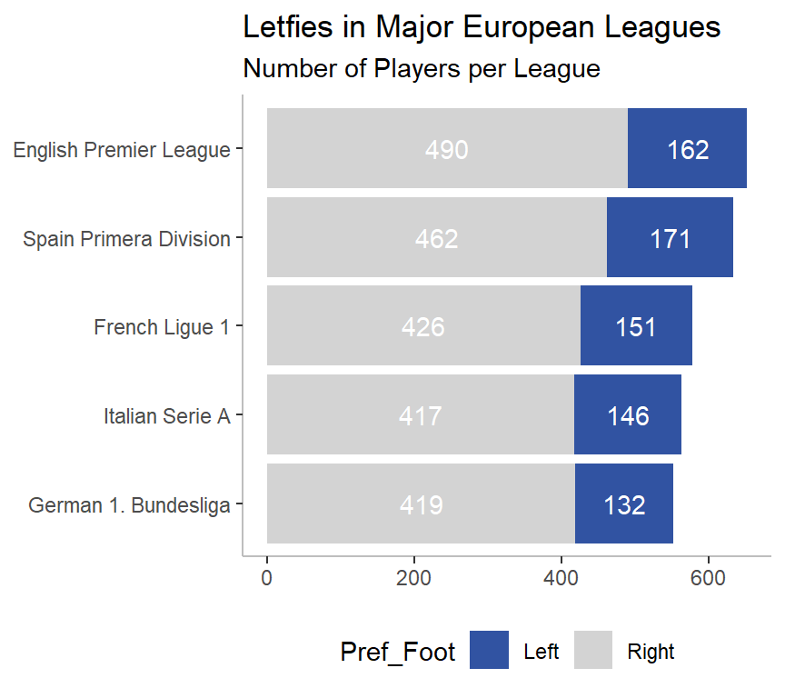

```r
#-----Theme defaults-----
theme_set(theme_bw() +
            theme(panel.grid.major = element_blank(),
                  panel.grid.minor = element_blank()))

#-----Stacked barplot-----
step_1 %$%
  ggplot(., aes(x=reorder(League,Count), y = Count, fill = Pref_Foot)) +
  geom_col() +
  geom_text(aes(label = format(Count, group = as_factor(Pref_Foot))),
            colour = "white", position = position_stack(vjust = 0.5)) +
  scale_fill_manual(values=c('#3153a2', 'lightgrey')) +
  ggtitle("Letfies in Major European Leagues",
          subtitle = "Number of Players per League") +
  theme(legend.position="bottom",
        axis.title.y = element_blank(),
        axis.title.x = element_blank(),
        panel.border = element_blank(),
        axis.line = element_line(colour = "grey")) +
  coord_flip()
```

**Task 4:** Complete the code below. Format data frame `step_1` as wide. Calculate total number of players per league and the proportions of left- and right-footed players. Append results to the table.

```r
 step_2 <- step_1 %>%
   pivot_wider(...) %>%
   mutate(...)

 step_2
```

```
## # A tibble: 5 × 6
##   League                  Left Right Total Prop_Left Prop_Right
##   <chr>                  <int> <int> <int>     <dbl>      <dbl>
## 1 English Premier League   162   490   652     0.248      0.752
## 2 French Ligue 1           151   426   577     0.262      0.738
## 3 German 1. Bundesliga     132   419   551     0.240      0.760
## 4 Italian Serie A          146   417   563     0.259      0.741
## 5 Spain Primera Division   171   462   633     0.270      0.730
```

**Conclusion:** It would be expected for left-footed players to constitute about 10% of player base. However, their prevalence is more than twice as much, suggesting that they are actively recruited.

### Lefties are Engaged in Offense

> Left-footing can make itself felt in a whole host of offensive scenarios, including players’ ability to come up with creative ideas and solutions, invent new tricks and capitalize on goal-scoring chances more quickly. Is this a myth or a fact?

If true, then football clubs will strive to engage more left-footers at offensive positions. Your task is to find `player_positions` at which left-footed players play and compare either position frequencies, or proportions to those from right-footers players.

This is a complex task, so we will break down the problem into several easier chunks. You should progress iteratively, starting with data slicing, transformations and raw count generation, etc.

- At step 1, extract player positions for left- and right-footed players.
- At step 2, generate raw counts for each player position.
- At step 3, classify players into offensive players, defensive players and midfielders. Aggregate player counts for each class.
- At step 4, convert raw count to percentages and group-compare offense vs. defense. You can use any suitable statistical test for step 4, but it is optional at this stage.

#### Extracting player roles

**Task 1:** Complete the code below to extract playing positions. Group by foot preference. Restrict to 5 national leagues mentioned above.

```r
step_1 <- data %>%
  filter(...) %>% # Use filter to select leagues of interest
  select(...) %>% # Use select to get columns you need
  group_by(...) %>% # Use group to aggregate data according to player's foot
  transmute(Position = strsplit(...)) %>%
  unnest(cols = Position) %>%
  rename(Pref_Foot = preferred_foot)

step_1 %>% print(n=3)
```

Once completed, print first three line to verify that you have correct table.

```
## # A tibble: 5,046 × 2
## # Groups:   Pref_Foot [2]
##   Pref_Foot Position
##   <chr>     <chr>
## 1 Left      RW
## 2 Left      ST
## 3 Left      CF
## # ℹ 5,043 more rows
```

#### Count players for each role

**Task 2:** Complete the code below. Use `ungroup()` to remove previous grouping by foot. Then re-apply `group_by()` to make a fresh grouping by foot and playing position. Pivot the table *wide* to get the desired table below.

```r
step_2 <- step_1 %>%
  ungroup() %>%
  group_by(...) %>% # Group data by foot preference and position
  summarise(...) %>% # Generate raw counts for each position
  pivot_wider(...) %>% # Spread
  mutate_all(., ...) # Convert missing values to 0

step_2
```

```
## # A tibble: 2 × 16
## # Groups:   Pref_Foot [2]
##   Pref_Foot   CAM    CB   CDM    CF    CM    GK    LB    LM    LW   LWB    RB
##   <chr>     <int> <int> <int> <int> <int> <int> <int> <int> <int> <int> <int>
## 1 Left        106   169    73    29   129    47   263   143    32    76     3
## 2 Right       258   472   408    79   570   279    57   240   130    12   312
## # ℹ 4 more variables: RM <int>, RW <int>, ST <int>, RWB <int>
```

#### Classify player roles

**Task 3:** Complete the code below. Classify player roles into one of the 3 categories: offense, defense and midfielders. Calculate total number of players in each category. Decide on which group CAM and CDM are included.

> There are 21 player roles (or positions at which they play), FIFA uses 15.

Offensive players are forwarders (CF), wingers (LW, RW) and strikers (ST). Defensive players play at back positions either as rear wingers (LWB, RWB,), centers (CB), or at flanks (LB, RB).

Goal keepers (GK) constitute a separate category, but you can count them as defense.

```r
step_3 <- step_2 %>%
  group_by(Pref_Foot) %>%
  transmute(Offense = ...,
            Defense = ...,
            Midfielders = ...)
step_3
```

```
## # A tibble: 2 × 4
## # Groups:   Pref_Foot [2]
##   Pref_Foot Offense Defense Midfielders
##   <chr>       <int>   <int>       <int>
## 1 Left          226     558         557
## 2 Right         726    1224        1755
```

**Task 4:** Complete the code below. Absolute numbers does not tells us much because each group has different totals.

```r
step_1 %>%
  group_by(Pref_Foot) %>%
  tally()
```

```
## # A tibble: 2 × 2
##   Pref_Foot     n
##   <chr>     <int>
## 1 Left       1341
## 2 Right      3705
```

A sensible approach is to compare the relative counts — i.e. the percentage of players in each category.

```r
# Create a 2 x 3 matrix with population totals.
popCounts <- matrix(rep(c(1341,3705),3), nrow = 2)

# Divide the relative counts from step 3 by population totals.
# Save the resulting matrix as step_4
step_4 <- ... / ...

step_4 %>%
  mutate(Foot = step_3$preferred_foot) %>%
  relocate(...) # Rearrange attributes as shown below.
```

```
##    Foot   Offense   Defense Midfielders
## 1  Left 0.1685309 0.4161074   0.4153617
## 2 Right 0.1959514 0.3303644   0.4736842
```

**Conclusion:** We can summarize all prior data on one stacked barplot. Lefties, it seems, are more engaged in defense, not offense.

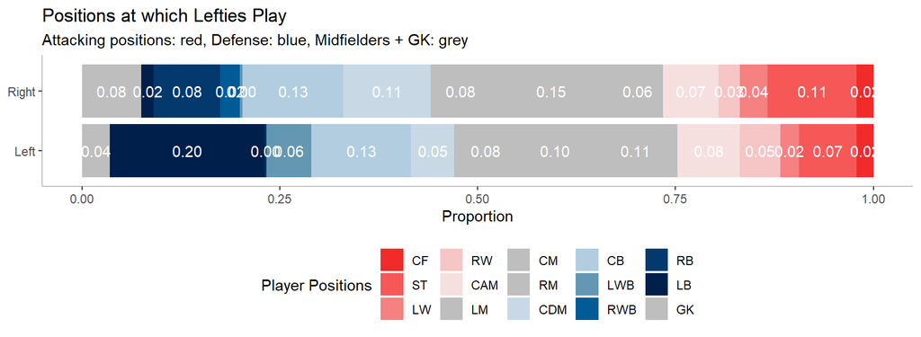

The truth is that if clubs cannot find a suitable left-footed forward, they may choose not to invest a large amount of money in that position. Instead, they might spend the money on a right-footed player whose value is more reasonable. So yes, this is a myth, not a fact.

Actually, there are more lefties playing defense. The reason for this is that left-sided defenders can more easily defend against right-footed attackers and can also provide a more natural attacking threat when moving up the field.